# Assignment Report

G17 - Francisco Gonçalves & João Aguiar

1/10/2021

# Introduction

For this assignment, our group was tasked with finding the most suitable data mining method in order to accurately predict the cause of a fire in Portugal which can be any of these types: negligent, intentional, rekindling or natural.

This information, along with other important variables, was obtained through a dataset of Portugal fires in 2015.

This report contains all the steps requested for this assignment as well as the respective analysis, justifications and conclusions.

# Problem definition

This assignment proposes the challenge of using different Data Mining techniques in order to predict the cause of fires in Portugal, with the best possible accuracy. The data necessary in order to answer such question is organized in the train and test datasets of the 2015 fires. Both are necessary to properly complete the proposed steps. They will be slightly adjusted along the various steps of this project by removing useless information or by changing certain data types to better suit our needs.

# Data pre-processing

In this first step, we focus on importing both the fires2015_train.csv and the fires2015_test.csv files into an appropriate R dataset. The latter will be used for all the Kaggle competition submissions. We also perform some clean-up in order to remove unwanted data and better adjust the remaining data to our needs. In order to properly test multiple prediction models as well as perform other essential tasks we required a multitude of packages such as dplyr, na.tools, lubridate to clean and organize the initial data and caret, performanceEstimation and randomForest among others for different techniques. Afterwards, our group felt it was necessary to slightly clean-up the available datasets. Therefore, we decided to remove the following variables:

- alert_source: It was a useless column as it only had zeros for all of its rows
- firstInterv_date: It didn’t provide a significant improvement in accuracy or have importance for the current task
- firstInterv_hour: Same reason as the variable above

The other variables still untouched like alert_date, alert_hour, extinction_date and extinction_hour were changed into date types.

As for all the others left unmentioned, those were already an acceptable data type.

The datasets were also inspected for any NA values and if that was the case, removed.

The final results for the train dataset would look like this in summary:

```
##        id                       region                 district
##  Min.   :   1   Entre Douro e Minho:2840   Porto           :1076
##  1st Qu.:1880   Beira Litoral      :1043   Viana do Castelo: 896
##  Median :3756   TrÃ¡s-os-Montes    :1026   Viseu           : 691
##  Mean   :3756   Ribatejo e Oeste   : 859   Vila Real       : 681
##  3rd Qu.:5634   Beira Interior     : 561   Braga           : 643
##  Max.   :7511   -                  : 500   SantarÃ©m       : 619
##                 (Other)            : 673   (Other)         :2896
##             municipality                       parish
##  Penafiel         : 258   TelÃµes                 :  44
##  Arcos de Valdevez: 218   Nossa Senhora de FÃ¡tima:  32
##  CinfÃ£es         : 167   Castelo Branco          :  30
##  Viana do Castelo : 162   CinfÃ£es                :  30
##  Amarante         : 154   SÃ£o Salvador           :  29
##  Celorico de Basto: 126   Sabadim                 :  29
##  (Other)          :6417   (Other)                 :7308
##                        lat                            lon
##  41:33:32.9184000000123'':  14   8:1:13.796399999997''  :  14
##  41:35:13.0127999999985'':  14   8:4:25.8420000000014'' :  14
##  41:39:14.4936000000064'':  14   8:40:24.5496000000017'':  14
##  41:42:16.0451999999924'':  13   8:40:31.2779999999989'':  13
##  41:21:55.785600000001'' :  12   8:0:48.877199999999''  :  12
##  41:38:29.000399999988'' :  12   8:14:18.8448000000028'':  12
##  (Other)                 :7423   (Other)                :7423
##          origin       alert_date         extinction_date
##  agric_burn : 339   Min.   :2015-01-01   Min.   :2015-01-01
##  agriculture:1320   1st Qu.:2015-04-07   1st Qu.:2015-04-07
##  false_alarm:   8   Median :2015-07-07   Median :2015-07-07
##  fire       :1559   Mean   :2015-06-20   Mean   :2015-06-20
##  firepit    :4276   3rd Qu.:2015-08-11   3rd Qu.:2015-08-11
##                     Max.   :2015-12-27   Max.   :2015-12-28
##
##   village_area      vegetation_area     farming_area      village_veget_area
##  Min.   :   0.000   Min.   :   0.000   Min.   :  0.0000   Min.   :   0.0000
##  1st Qu.:   0.000   1st Qu.:   0.000   1st Qu.:  0.0000   1st Qu.:   0.0040
##  Median :   0.000   Median :   0.015   Median :  0.0000   Median :   0.0539
##  Mean   :   2.034   Mean   :   2.857   Mean   :  0.2362   Mean   :   4.8913
##  3rd Qu.:   0.020   3rd Qu.:   0.270   3rd Qu.:  0.0000   3rd Qu.:   0.5500
##  Max.   :1548.920   Max.   :2543.560   Max.   :165.0000   Max.   :3023.9900
##
##    total_area              cause_type
##  Min.   :   0.0000   intentional:2160
##  1st Qu.:   0.0181   natural    : 105
##  Median :   0.1000   negligent  :4164
##  Mean   :   5.1275   rekindling :1073
##  3rd Qu.:   0.8000
##  Max.   :3023.9900
##
```

It must be noted that this dataset would still suffer more changes later when testing different models in search for the best possible prediction accuracy.

# Exploratory data analysis

For this next step, we used the available data to answer pertinent questions and provide useful insight on the matter through . Therefore, we came up with a few questions that could do just that, such as:

### 1) Region with most fires:

```
## # A tibble: 5 x 2
##   region              fires
##   <ord>               <int>
## 1 Entre Douro e Minho  2840
## 2 Beira Litoral        1043
## 3 TrÃ¡s-os-Montes      1026
## 4 Ribatejo e Oeste      859
## 5 Beira Interior        561
```

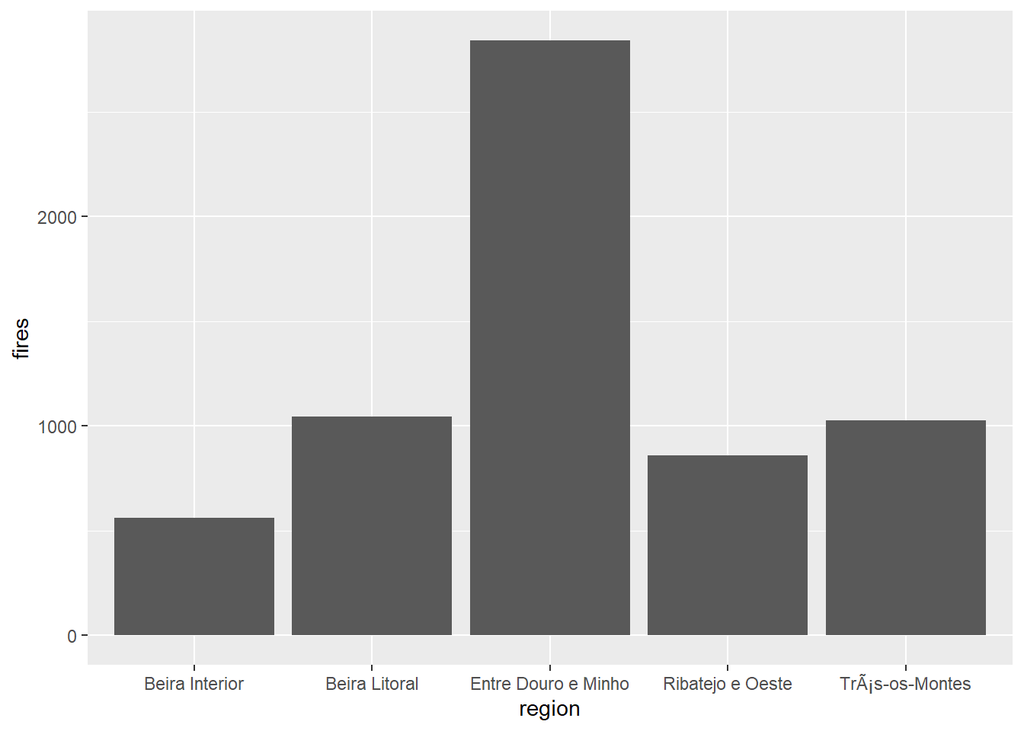

### 2) Most common type of fire:

```
## # A tibble: 4 x 2
##   cause_type  fires
##   <ord>       <int>
## 1 negligent    4164
## 2 intentional  2160
## 3 rekindling   1073
## 4 natural       105
```

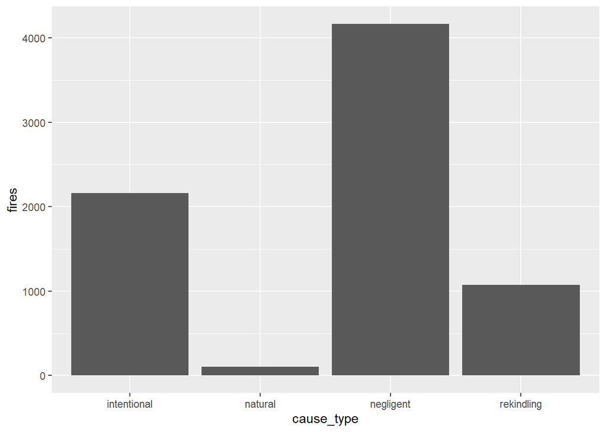

### 3) Most common origin:

```
## # A tibble: 5 x 2
##   origin      fires
##   <ord>       <int>
## 1 firepit      4276
## 2 fire         1559
## 3 agriculture  1320
## 4 agric_burn    339
## 5 false_alarm     8
```

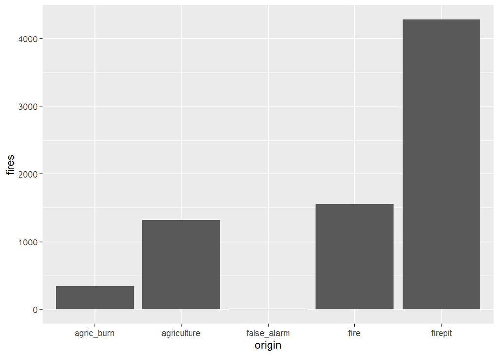

### 4) Fire that took the most time to put out:

```
## # A tibble: 5 x 2
## # Groups:   parish [5]
##   parish             time
##   <ord>              <drtn>
## 1 Cepelos            18 days
## 2 Nespereira         12 days
## 3 Salir de Matos      7 days
## 4 Candemil            6 days
## 5 Mangualde da Serra  5 days
```

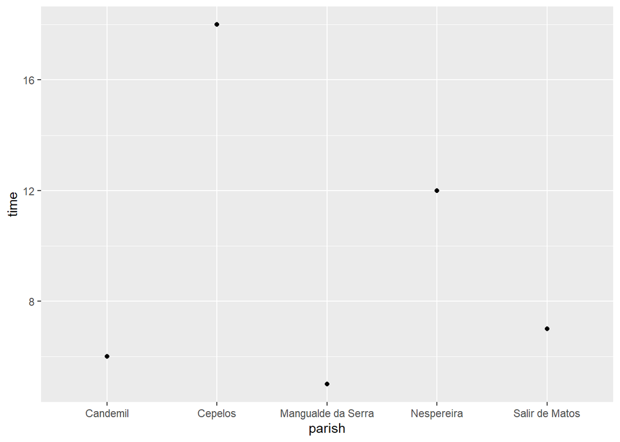

# Predictive modelling

In this step, we use the previous train dataset and use it to generate new and more specific datasets according to the method used in order to obtain the most efficient model. The models shown here are sorted by accuracy obtained, starting with the best outcome.

### Random Forests:

```
##
## Call:
##  randomForest(formula = cause_type ~ ., data = fires_train, mtree = 901,      mtry = 7, importance = TRUE)
##                Type of random forest: classification
##                      Number of trees: 500
## No. of variables tried at each split: 7
##
##         OOB estimate of  error rate: 38.68%
## Confusion matrix:
##             intentional natural negligent rekindling class.error
## intentional         687       8       628        189   0.5456349
## natural              19      19        30          6   0.7432432
## negligent           482       4      2256        173   0.2260720
## rekindling          238       4       251        259   0.6555851
```

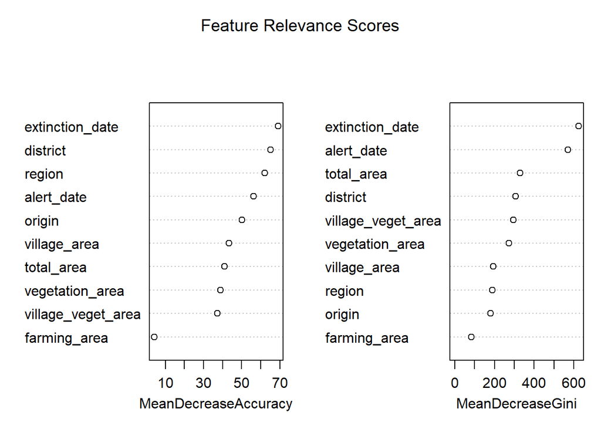

```
##  Accuracy
## 0.6167185
```

As seen through the printed accuracy results of the confusion matrix calculated from the Random Forests’ predictions, by creating a data partition of the given train dataset and using the remaining data as a test set the most accuracy was obtained out of all the models tested.

The following models showed less desirable results in comparison, therefore our group considered the choice of the Random Forests model as the final model. The results obtained from the other models are the following:

### K-NN:

```
##  Accuracy
## 0.6007993
```

### Naive Bayes:

```
##  Accuracy
## 0.4427176
```

# Kaggle Competition:

For this step of the assignment, the final result obtained counted on an accuracy score of 0.63765, using the predictions obtained from the Random Forests model. The procedures for making predictions were roughly the same as in the previous step, altough a given test dataset was used instead of a partitioned train set. The results obtained through Kaggle were close to the values previously obtained locally.

# Conclusions

The results obtained could have been improved by at least 10% by including the additional weather information, however, our group was unable to use that tool efficiently. Overall, it is still a somewhat reliable prediction method.

Throughout this assignment, it became fascinating how much information, directly or indirectly, one can get out of a dataset and, with a goal in mind, that cluster of data can be combined with others, improved and cleaned up for precise predictions into the future, which is indubitably an incredibly powerful tool in the current society. In this case, it was applied to the causes of fires in Portugal but it can be applied to so much more, so long as there’s data on the subject and, in our current world, data is everywhere.

It also became astounding how such a little change in the dataset or in one of its variables can greatly affect the accuracy of the prediction of the same model.